# Data Visualization with ggplot2

Berk Orbay

# Introduction

This is a follow up tutorial of the dplyr elections tutorial. In this document we are going to learn the basics of ggplot2, one of the best data visualization packages of R.

### Where is the data?

For starters, **[here is the data](https://github.com/berkorbay/datasets/raw/master/local_elections_2019/local_election_20190623_education.rds)**.

```r
library(tidyverse) #tidyverse includes both dplyr and ggplot2
raw_df <- readRDS("local_election_20190623_education.rds")
```

# Fundamental Plots

Different from dplyr we do not use the pipe (`%>%`), but the plus sign (`+`). Actually we do not chain commands in ggplot2, but we start with a “canvas” and add layers. The canvas is called a `ggplot2()` function Then for x and y axes, we define an “(aes)thetic” with the `aes()` function inside ggplot2.

## Scatter Plot

Scatter plot or dot plot is represented by the geom_point(). For instance let’s plot votes of AK PARTI and CHP.

We start with preparing our data. We need a data in the long format (hence, `pivot_longer` function).

```r
plot_df <- raw_df %>% filter(ilce_ADI == "ADALAR") %>% group_by(muhtarlik_ID,muhtarlik_ADI) %>% summarise(AK_PARTI = sum(AK_PARTI), CHP = sum(CHP)) %>% ungroup() %>% pivot_longer(cols=CHP:AK_PARTI,names_to="party",values_to="votes")
print(plot_df,n=3)
```

```
## # A tibble: 10 x 4
##   muhtarlik_ID muhtarlik_ADI  party    votes
##   <chr>        <chr>          <chr>    <dbl>
## 1 95626        BURGAZADA MAH. CHP        874
## 2 95626        BURGAZADA MAH. AK_PARTI   177
## 3 95627        MADEN MAH.     CHP       2070
## # … with 7 more rows
```

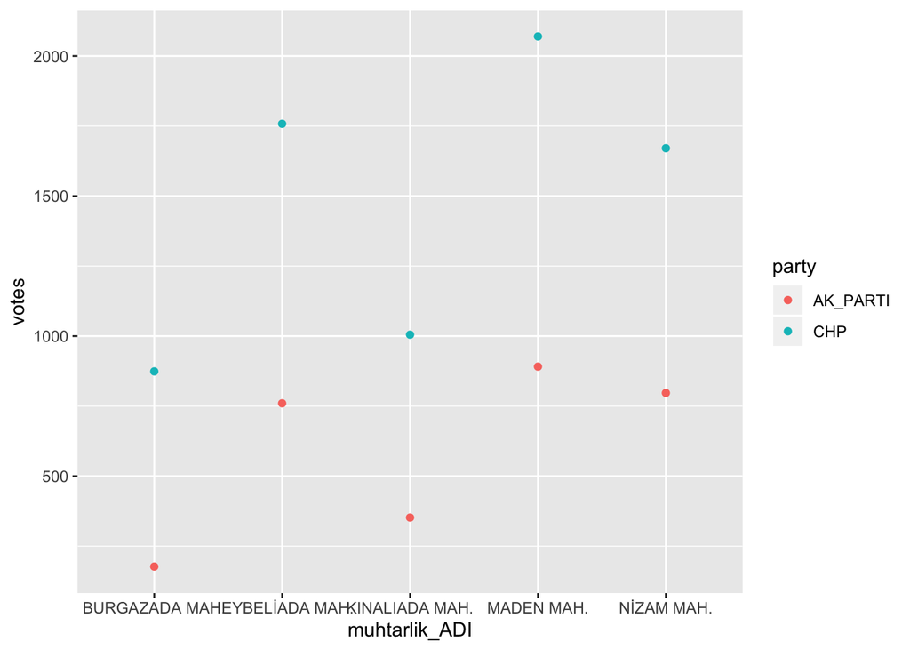

```r
scplot <- ggplot(plot_df,aes(x=muhtarlik_ADI,y=votes,color=party)) + geom_point()
scplot
```

Congratulations! You did your first plot. Other plots have very similar attributes. But before that, let’s make our plot more beautiful. First let’s remove all the gray background with a predefined “theme” (there are very interesting themes in ggplot2).

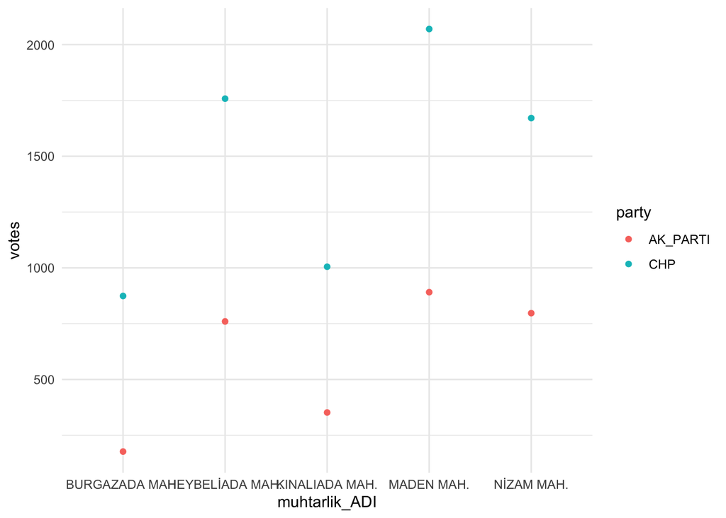

```r
scplot + theme_minimal()
```

Then let’s change label names, add a title, rotate x axis text.

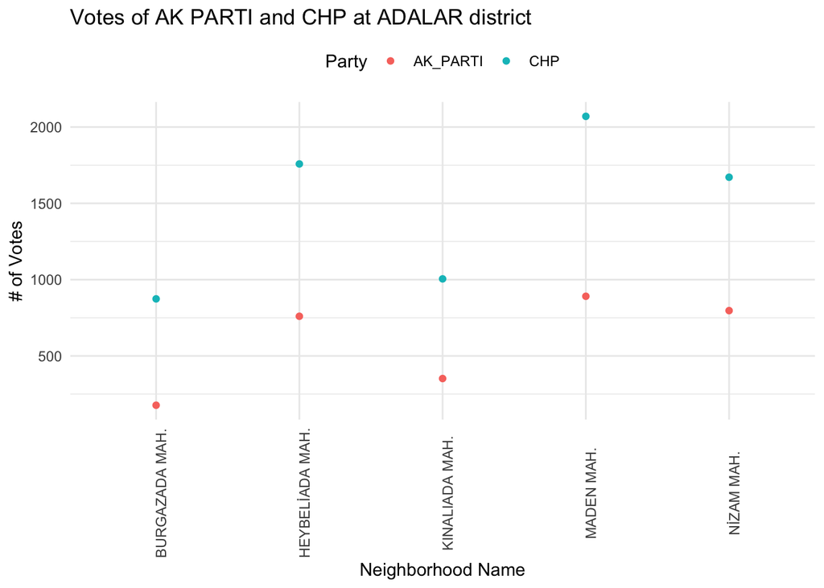

```r
scplot +
  theme_minimal() +
  labs(x="Neighborhood Name",y="# of Votes",title="Votes of AK PARTI and CHP at ADALAR district",color="Party") +
  theme(axis.text.x = element_text(angle=90),legend.position = "top")
```

## Bar Chart

Bar chart is very similar to `geom_point`, now we use `geom_bar`. And instead of `color` we use `fill`.

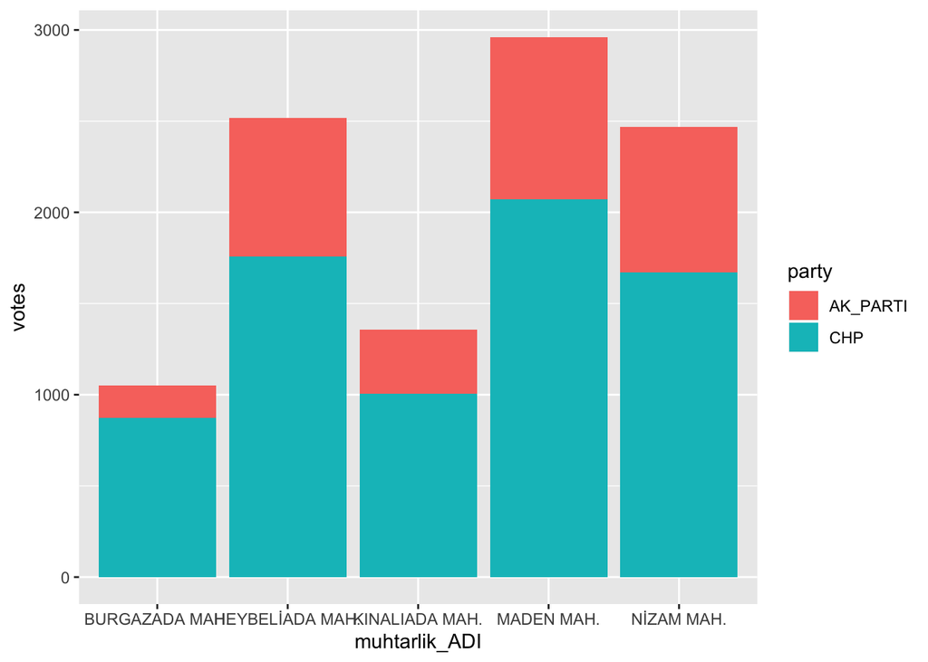

```r
ggplot(plot_df,aes(x=muhtarlik_ADI,y=votes, fill=party)) + geom_bar(stat="identity")
```

But it is not quite what we wanted. It would be better if it is side by side.

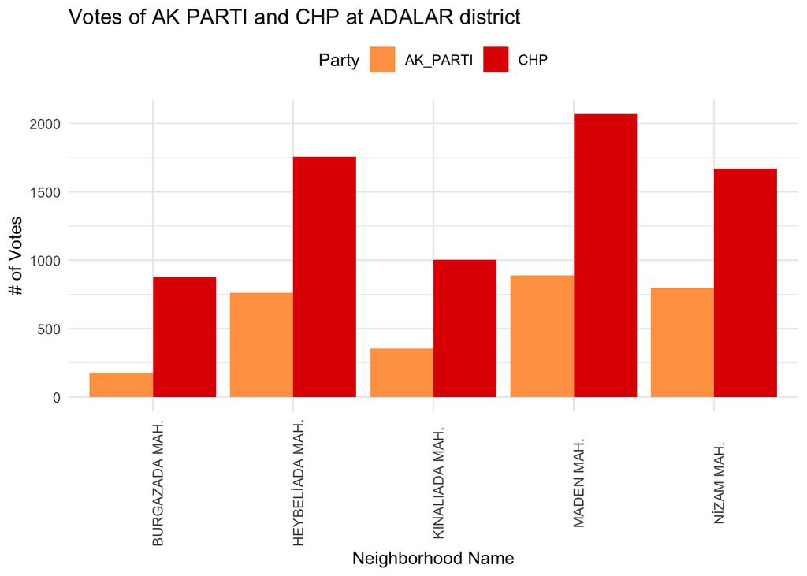

```r
ggplot(plot_df,aes(x=muhtarlik_ADI,y=votes, fill=party)) + geom_bar(stat="identity",position="dodge") +
  theme_minimal() +
  labs(x="Neighborhood Name",y="# of Votes",title="Votes of AK PARTI and CHP at ADALAR district",fill="Party") +
  theme(axis.text.x = element_text(angle=90),legend.position = "top") +
  scale_fill_manual(values=c("#FFA351FF","#E10600FF"))
```

# References

- Data Set: [23 Haziran 2019 İstanbul Büyükşehir Belediye Başkanlığı Yenileme Seçimi Sonuçları](https://sonuc.ysk.gov.tr/sorgu)
- Tidyverse: https://www.tidyverse.org/
- R for Data Science: https://r4ds.had.co.nz/
- Cheatsheet: [Data Transformation](https://github.com/rstudio/cheatsheets/raw/master/data-visualization-2.1.pdf)